# Семинар 7 (04.12.2025). Молекулярная динамика 2: белок в мембране

# 1. Введение

## 1.1. Мембранные белки

## 1.2. Программы для сборки мембранных систем

[figure not shown]

Существует множество программ, с помощью которых можно собрать мембранную систему:

- **CHARMM-GUI Membrane Builder** https://www.charmm-gui.org/?doc=input/membrane.bilayer
  - Наиболее популярная программа для сборки систем "белок в мембране"
  - Автоматизированный веб-интерфейс
  - Поддержка множества типов мембран: плоские моно/бислои, мицеллы, липидные нанодиски, везикулы
  - Большая библиотека липидов и детергентов (сотни типов) и готовые входные файлы для основных MD‑пакетов (CHARMM, AMBER, OPLS и др.).
- **MemBuilder** https://maayanlab.cloud/datasets2tools/landing/tool/MemBuilder
  - Веб‑интерфейс для сборки бислоев под GROMACS; поддержка асимметричных мембран
  - Выдает топологии и координаты системы после минимизации энергии.
  - Встроенная база ~18 липидов (меньше, чем у CHARMM-GUI) и несколько силовых полей (GROMOS96 варианты и Slipid/Amber); опционально добавляет воду и ионы до нужной ионной силы
- **HTMD Membrane Builder** https://software.acellera.com/htmd/tutorials/MembraneBuilder.html
  - Сборка мембраны с помощью скриптов: построение бислоя в Python, задание размеров по XY и состава верхнего/нижнего листков словарями; есть просмотр и автоматическая минимизация/уравновешивание.
  - Расширяемость: добавление новых липидов (из PDB) и CSV с APL/толщиной/головной группой;
  - Упор на программируемые пайплайны.
- **Curved Membrane (Cmem) Builder** https://cmembuilder.com/
  - Специализация: автоматическая генерация изогнутых мембран и комплексов «белок–мембрана» для крупнозернистого (coarse grain) молекулярной динамики (CS-MD, силовое поле Martini), с заданной кривизной
- И другие (например, наш внутренний **программный пакет Импульс**, используемый в нашей лаборатории)...

## Пайплайн CHARMM-GUI

[figure not shown]

# 2. Практика

## 2.1. Модельный белок: **MELLITIN**

- **Мелиттин** — основной компонент пчелиного яда, составляет примерно 35–50% сухой массы яда.
- Представляет собой катионный амфифильный пептид из 26 аминокислот с молекулярной массой около 2840 Да.

[figure not shown]

*Структура меллитина*

*Hong J, Lu X, Deng Z, Xiao S, Yuan B, Yang K. How Melittin Inserts into Cell Membrane: Conformational Changes, Inter-Peptide Cooperation, and Disturbance on the Membrane. Molecules. 2019;24(9):1775. https://doi.org/10.3390/molecules24091775.*

- Обладает свойствами детергента: связывается с мембранами, образует поры, повышает проницаемость и вызывает лизис клеток (в т. ч. гемолиз).
- Проявляет антибактериальные, противовирусные, противогрибковые и противоопухолевые эффекты, но действует неселективно и очень цитотоксичен.
- Рассматривается как перспективный компонент для противоопухолевой терапии и адъювантной иммунотерапии, однако требует модификаций для снижения токсичности.

[figure not shown]

*Предполагаемая модель взаимодействия мелиттина с мембраной*

*Zhang HQ, Sun C, Xu N, Liu W. "The current landscape of the antimicrobial peptide melittin and its therapeutic potential." Front. Immunol. 2024;15:1326033. https://doi.org/10.3389/fimmu.2024.1326033*

- Структура: https://www.rcsb.org/structure/2MLT - тетрамер меллитина с 4 $SO_4$ группами и молекулами $H_2O$

[figure not shown]

## 2.2. Сборка системы в CHARMM-GUI

### Подготовка

Для сборки системы мы будем использовать CHARMM-GUI Membrane Builder

1. Сайт CHARMM-GUI https://www.charmm-gui.org/ - заходим, регистрируемся с почты phystech.edu
2. Input Generator > Membrane Builder

### Step 0: Загрузка структуры белка

- Выбираем PDB_ID

[figure not shown]

- Выбираем нужные компоненты из нашей структуры: в данном случае, выбрана только цепь A (димер меллитина)

[figure not shown]

- На следующей странице сохраняем все по-умолчанию

[figure not shown]

### Step 1: Ориентация белка

На этом шаге нужно выбрать ориентацию белка (как он будет расположен в мембране)

- Проверяем , что выбран димер меллитина (step1_pdbreader.pdb -> view structure)

[figure not shown]

- В `Orientation Options` выбираем `Align the pirst principal axis along Z` - для простых пучков альфа-спиралей программа определит ось спирали и соотнесет ее с осью Z, перпендикулярной плоскости бислоя

### Step 2: Определение размера и состава мембраны

Переходим на следующую вкладку и открываем структуру `Oriented PDB: step2_orient.pdb`

- Здесь плоскостями отображена будущая поверхность мембраны.
- Видим, что димер правильно ориентирован относительно нее.

[figure not shown]

Ниже можно посмотреть на площадь поперечного сечения димера вдоль вертикальной оси Z (перпендикулярной мембране)

[figure not shown]

Далее нужно выбрать состав и размер мембраны, в которую будет встроен белок.

- Размер мембраны в плоскости XY зададим 60 А (что соответствует небольшому бислою ~50 липидов на монослой)
- Состав - 100% липидов POPC
  > - Бислой POPC - распространенный модельный бислой в случаях, когда мембрана используется только для создания нативного окружения мбранного белка, т.е. как "растворитель белка".
  > - Когда важны свойства мембраны, например, когда они потенциально могут влиять на функционирование исследуемого белка, можно задавать более сложную композицию, схожую с нативным липидным окружением (например, плазматическая мембрана животных и т.д., см. Predefined Membrane в разделе https://www.charmm-gui.org/?doc=input/membrane.quick )

[figure not shown]

Проверяем заданную композицию кнопкой `Show the system info`

### Step 3: Выбор растворителя

Посмотрим на "упаковку" системы в `Packing Simulation: step3_packing.pdb`. Здесь точками показаны будущие головки липидов, рамкой отмечен бокс (периодические граничные условия), можно увидеть периодические изображения белка. Важно убедиться, что периодические "изображения" белка находятся на достаточном расстоянии, чтобы не влиять друг на друга.

[figure not shown]

- Далее можно выбрать метод, с помощью которого белок будет вставлен в бислой (оставляем по-умолчанию)
- Также, на этом шаге выбирается растворитель. Часто выбирают 150мМ NaCl или KCl, основываясь на стандартных концентрациях ионов. При этом ионы добавляются таким образом, чтобы нейтрализовать суммарный заряд системы.

[figure not shown]

*Типичные концентрации ионов*

*Dijkstra K, Hofmeijer J, van Gils SA, van Putten MJAM. A Biophysical Model for Cytotoxic Cell Swelling. Journal of Neuroscience. 2016;36(47):11881–11890. doi: https://doi.org/10.1523/JNEUROSCI.1934-16.2016*

[figure not shown]

### Step 4: Сборка системы

[figure not shown]

Если нет предупреждений, то на этом шаге ничего делать не надо, просто нажимаем `Assemble components`.

### Step 5: Генерация выходных файлов

Итак, система "мембрана+белок" собрана!

[figure not shown]

В `Assembled PDB: step5_assembly.pdb` можно на нее посмотреть:

[figure not shown]

Теперь нужно выбрать формат выходных файлов.

- Т.к. мы используем GROMACS для расчетов МД, то выбираем его.
- Также, на этом шаге нужно выбрать ансамбль моделирования (NPT) и температуру (например, 310 К = 36 °C)

[figure not shown]

### Step 6: Скачивание файлов из CHARMM-GUI

[figure not shown]

Сгенерированные файлы можно скачать (`download.tgz` в правом верхнем углу). Результат - архив `charmm-gui.tgz` (он же распакован в папку `Seminars/Seminar7/charmm-gui-6459390172`)

## 2.3. Расчет МД на кластере

### Пайплайн уравновешивания

- **Цель уравновешивания**: постепенно снять ограничения на движение атомов, чтобы избежать артефактов и "поломки" структуры после сборки.
- **Типы ограничений**:
  - **BB**: позиционные ограничения на остов белка (backbone).
  - **SC**: позиционные ограничения на боковые цепи белка (sidechains).
  - **wforce**: позиционные ограничения на воду (обычно по оси Z).
  - **tforce**: позиционные ограничения на хвосты липидов (tails).
  - **mforce**: позиционные ограничения на головные группы липидов ("mid"/"headgroup").
  - **ion**: позиционные ограничения на ионы (Na+, Cl^-) — только на старте.
- Позиционные ограничения прописывают в файлах топологий `.itp`, например, в файле `PROA.itp`:

  ```
  #ifdef POSRES
  [ position_restraints ]
      1     1    POSRES_FC_BB    POSRES_FC_BB    POSRES_FC_BB
      5     1    POSRES_FC_BB    POSRES_FC_BB    POSRES_FC_BB
      8     1    POSRES_FC_BB    POSRES_FC_BB    POSRES_FC_BB
  ...
  #endif
  ```

- В файлах параметров каждого из шагов уравновешивания (`.mdp`) в строчке `define=` указано, какие ограничения будут включены на данном шаге. Например, в файле `step6.0_minimization.mdp`:

  `define = -DPOSRES -DPOSRES_FC_BB=4000.0 -DPOSRES_FC_SC=2000.0 -DPOSRES_FC_LIPID=1000.0 -DDIHRES -DDIHRES_FC=1000.0`

**Схема уравновешиания**

- На каждом цикле величина коэффициентов сил позиционных ограничений постепенно снижается:
- Первый цикл: шаг интегрирования 1 фс, чтобы снизить риск ошибок интегратора на неравновесной системе. Далее dt становится 2 фс.

[figure not shown]

### Запуск расчета

Рабочая директория с примером из семинара: `/home/veretenenko/MolMod-2025/MELITTIN`

Для запуска расчета на кластере нужно выполним следующие шаги:

1. Копируем папку `charmm-gui-xxx/gromacs` в свою директорию на кластере
2. Переделываем README в run.sh
   1. Прописываем параметры запуска (путь к Gromacs, номер GPU, число CPU):

      ```
      # на go
      source /usr/local/gromacs-2024.4/bin/GMXRC
      set GPU_ID      = 0 # номер GPU
      set NT          = 10 # число ядер, которые займем под расчет
      set PINOFFSET   = 0 # номер 1го ядра, с которого займем NT ядер
      ```

   2. Во все gmx mdrun добавляем флажки для МД на нужных ядрах и карточке

      ```
      -gpu_id $GPU_ID -nt $NT -pin on -pinoffset $PINOFFSET -pinstride 1 -nb gpu -bonded gpu -pme gpu -pmefft gpu -update gpu -cpi -cpo -cpt 15
      ```

   3. В production ставим `set cntmax = 1` (т.к. будем считать одну траекторию)
3. В файле `step7_production.mdp` выставляем нужную длину траектории: значения `dt=0.002` (ps) и `nsteps=500000` соответствуют $500000\cdot0.002=1000\ ps = 1\ ns$
4. Запуск расчета:

   ```
   nohup ./run.sh &
   ```

## 2.4. Постобработка траектории

### 2.4.1. Визуализация траектории

#### PyMOL

- Скопируем файл с финальными координатами `step7_1.gro` и файл траектории `step7_1.xtc` в локальную директорию.
- Откроем `step7_1.gro` в PyMOL
- Далее загрузим траекторию `step7_1.xtc` `File -> Open`

[figure not shown]

Результат:

[figure not shown]

Так произошло из-за периодических граничных условий: части молекул липидов и воды оказались по разные стороны от границ бокса.

Чтобы этого избежать, нужно с помощью `gmx trjconv` центрировать белок по центру бокса (`-center`) и "сохранить молекулы целиком" (`-pbc mol`). Выбираем группу центрирования `1 (Protein)` и группу для вывода `0 (System)`

```
gmx trjconv -f step7_1.xtc -s step7_1.tpr -center -pbc mol -o step7_1_out.xtc
```

Повторим аналогичные действия и получим аккуратную траекторию (см. `step7_5ns.pse`)

[figure not shown]

Сохраним видео с траекторией (см. https://pymol.org/dokuwiki/doku.php?id=setting:movie)

```
set movie_fps, 10
movie.produce step7_pymol.gif
```

#### Nglview

Другой способ визуализации - прямо в jupyter-ноутбуке с помощью MDAnalysis+Nglview. Данный способ плохо работает для больших траекторий, но для короткой может быть достаточно удобным.

```python
import MDAnalysis as mda

import nglview as nv
from nglview.contrib.movie import MovieMaker
```

```python
u = mda.Universe("step7_1.tpr", "step7_1_out.xtc")

view = nv.show_mdanalysis(u)

view.add_representation('ball+stick', selection='POPC and .P', radius=1, color="salmon")
view.add_representation('ball+stick', selection='POPC', radius=0.25, color="grey", opacity=0.05)

view.add_cartoon("protein", color='navy')
view.add_surface("protein", color='skyblue', opacity=0.05)
view.add_unitcell()

#view.camera='orthographic'
# view.control.zoom(0.1)
# view.control.rotate(
#         mda.lib.transformations.quaternion_from_euler(
#             0, 0, 0, 'rzyz').tolist())

view
```

```
NGLWidget(max_frame=50)
```

```python
movie = MovieMaker(
    view,
    output='step7_nglview.gif',     # .gif, .mp4, .avi, ...
    fps=10,
    in_memory=True,        # avoids browser downloads; good for local use
    start=0,               # first frame index
    stop=-1,               # last frame (-1 = all frames)
    step=1                 # stride
)
movie.make()
```

```
IntProgress(value=0, description='Rendering ...', max=50)
```

### 2.4.2. Распределение усредненных по МД-траектории параметров системы

Для анализа систем "белок в мембране" используют следующие параметры:

- Профили плотности различных компонентов системы (белка, липидов, воды и т.д.)
- Параметры бислоя:
  - Площадь на липидную головку
  - Порядок ацильных цепей по дейтерию
  - Толщина бислоя
  - Латеральная диффузия липидов
- Параметры белка:
  - RMSD
  - вторичная структура пептида
  - наклон спирали
- Контакты белок-белок/белок-липиды/липид-липид: водородные связи, ионные мостики и т.д.
- Распределения гидрофобных и электростатических свойств на молекулярных поверхностях системы

И, конечно, многое другое :)

```python
from MDAnalysis.analysis import lineardensity

import numpy as np
import matplotlib.pyplot as plt
```

#### Информация о системе

```python
u = mda.Universe("step7_1.tpr", "step7_1_out.xtc")   # adapt to your files

print("Universe info:")
print("\nBox dimensions[x,y,z]: {}." \
      "".format(u.dimensions[:3]))

print("\n{} residues and {} atoms." \
      "".format(u.residues.n_residues, u.residues.n_atoms))

print("\nThe trajectory includes {} frames."\
      "".format(u.trajectory.n_frames))

protein  = u.select_atoms("protein")
print("\nProtein has {} residues." \
      "".format(protein.n_residues))

lipids  = u.select_atoms("not protein")
print("\nLipids molecules include {} residues and {} atoms." \
      "".format(lipids.n_residues, lipids.n_atoms))
```

```
Universe info:

Box dimensions[x,y,z]: [59.009598 59.009598 77.471   ].

5030 residues and 28048 atoms.

The trajectory includes 51 frames.

Protein has 52 residues.

Lipids molecules include 4978 residues and 27176 atoms.
```

#### Распределение средней плотности атомов вдоль оси Z

```python
lipids = u.select_atoms("resname POPC")      # or your lipid resnames
water  = u.select_atoms("resname TIP3")
headgroups    = lipids.select_atoms("name P N C12 C13 C14 C15")   # example
glycerol_ester = lipids.select_atoms("name C21 C22 C31 C32 O21 O31")  # example
acyl_chains   = lipids.select_atoms("name C2? C3? C4? C5? C6? C1?")   # all tail carbons

protein = u.select_atoms("protein")   # or a more specific selection


binsize = 1  # Å resolution along z

ld_head = lineardensity.LinearDensity(headgroups,
                                      grouping='atoms',
                                      binsize=binsize).run()
ld_gly  = lineardensity.LinearDensity(glycerol_ester,
                                      grouping='atoms',
                                      binsize=binsize).run()
ld_acyl = lineardensity.LinearDensity(acyl_chains,
                                      grouping='atoms',
                                      binsize=binsize).run()
ld_wat  = lineardensity.LinearDensity(water,
                                      grouping='atoms',
                                      binsize=binsize).run()

ld_prot = lineardensity.LinearDensity(
    protein,
    grouping='atoms',        # per-atom mass density
    binsize=binsize          # same binsize as for lipids/water
).run()


z_edges = ld_head.results.z['hist_bin_edges']          # shape (nbins+1,)
z_centers_A = 0.5 * (z_edges[1:] + z_edges[:-1])

# convert to nm
z = z_centers_A / 10.0

rho_head = ld_head.results.z['mass_density'] * 1000.0
rho_gly  = ld_gly.results.z['mass_density'] * 1000.0
rho_acyl = ld_acyl.results.z['mass_density'] * 1000.0
rho_wat  = ld_wat.results.z['mass_density'] * 1000.0
rho_prot = ld_prot.results.z['mass_density'] * 1000.0  # g/cm^3 → kg/m^3
```

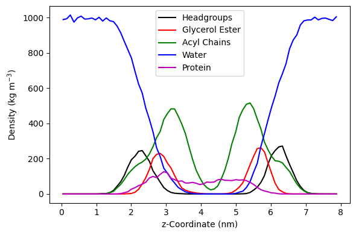

```python
plt.figure(figsize=(6,4))

plt.plot(z, rho_head, 'k-', label="Headgroups")
plt.plot(z, rho_gly,  'r-', label="Glycerol Ester")
plt.plot(z, rho_acyl, 'g-', label="Acyl Chains")
plt.plot(z, rho_wat,  'b-', label="Water")
plt.plot(z, rho_prot, 'm-', label="Protein")   # magenta example

plt.xlabel("z-Coordinate (nm)")
plt.ylabel(r"Density (kg m$^{-3}$)")
plt.legend()
plt.tight_layout()
plt.show()
```

```python
np.unique(protein.segids)
```

```
array(['seg_0_PROA', 'seg_1_P2PROA'], dtype=object)
```

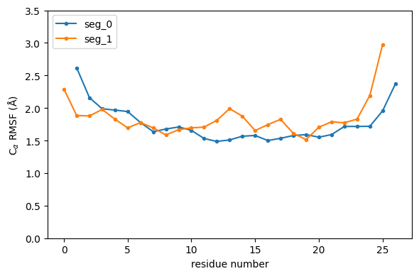

```python
def rmsf_from_calphas(ca):
    means = np.zeros((len(ca), 3))
    sumsq = np.zeros_like(means)

    for k, ts in enumerate(u.trajectory):
        sumsq += (k / (k + 1.0)) * (ca.positions - means)**2
        means[:] = (k * means + ca.positions) / (k + 1.0)

    return np.sqrt(sumsq.sum(axis=1) / (k + 1.0))

ca0 = u.select_atoms("segid seg_0* and protein and name CA")
ca1 = u.select_atoms("segid seg_1* and protein and name CA")

rmsf0 = rmsf_from_calphas(ca0)
rmsf1 = rmsf_from_calphas(ca1)

plt.figure(figsize=(6,4))
plt.plot(ca0.residues.resids, rmsf0, '.-', label="seg_0")
plt.plot(ca1.residues.resids - np.min(ca1.residues.resids), rmsf1, '.-', label="seg_1")

plt.ylim(0, 3.5)

plt.xlabel("residue number")
plt.ylabel(r"C$_\alpha$ RMSF (Å)")
plt.legend()
plt.tight_layout()
plt.show()
```

> Туториалы:
> - https://tutorials.gromacs.org/membrane-protein.html
> - http://www.mdtutorials.com/gmx/membrane_protein/
> - Папка `Materials`

# 3. Задание

- Собрать систему "мембрана+белок" в CHARMM-GUI
  - Белок:
    - Если ваш проектный белок - мембранный, то нужно взять его
    - Иначе, в RSB PDB можно найти 1-2 трансмембранные спирали / вырезать в PyMOL 1-2 трансмембранные спирали из большого белка
  - Мембрана: в простейшем случае, можно использовать мембрану POPC. Если интересно, можете попробовать собрать мембрану другого состава (см. Predefined Membrane в разделе https://www.charmm-gui.org/?doc=input/membrane.quick)
- Запустить все шаги уравновешивания и production МД (в течение 1 нс) на кластере
- Выполнить постобработку: записать видео с МД-траекторией, построить графики средних параметров системы вдоль МД-траектории

Прислать:

- собранную систему (файл charmm-gui.tgz)
- путь к папке, где была проведена МД
- видео с МД-траекторией
- графики средних параметров системы